# 1. INTRODUCTION

### Model 3: GAM

**Visualize Bivariate Relationships:** Start by creating bivariate plots between each predictor and the outcome variable to identify any nonlinear associations.

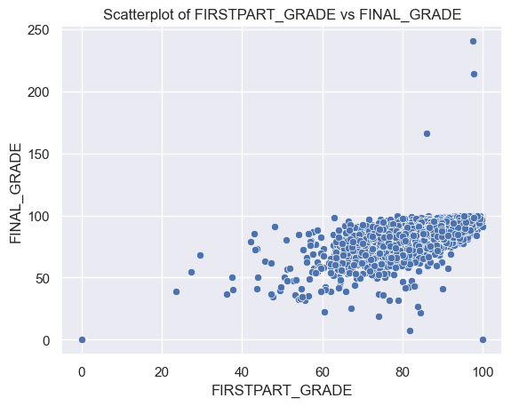

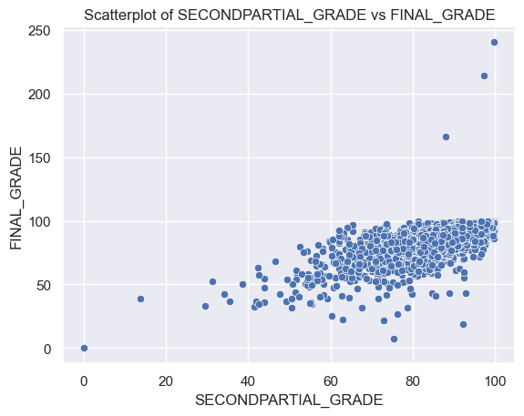

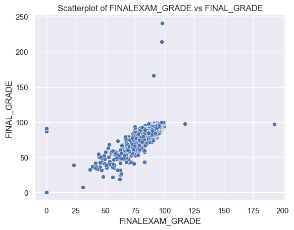

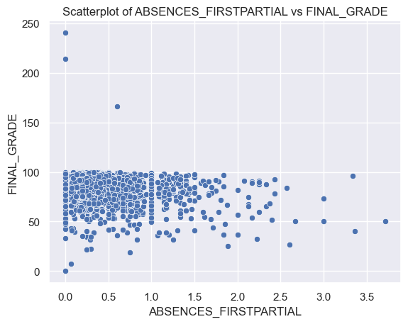

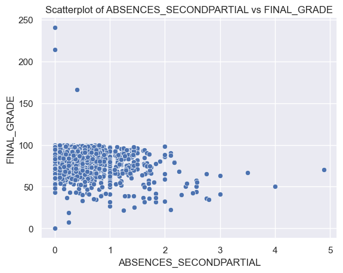

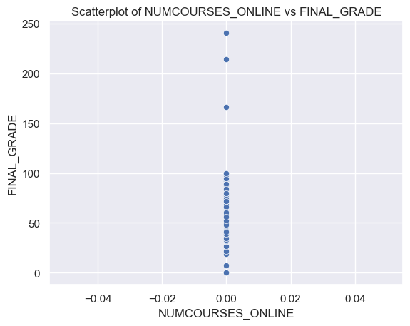

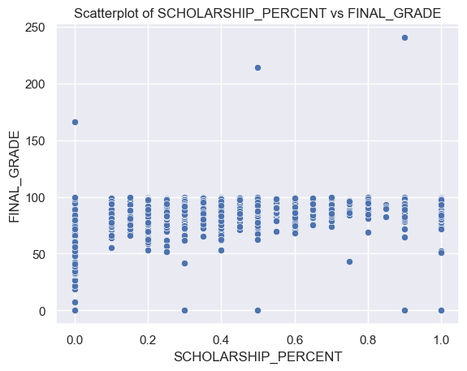

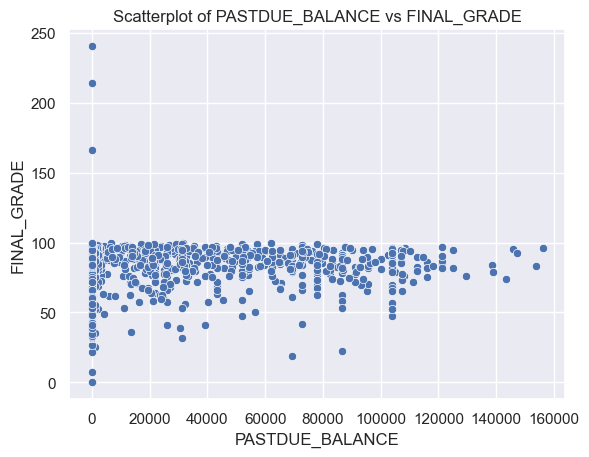

```python
import seaborn as sns
import matplotlib.pyplot as plt

# List of numerical predictors
numerical_predictors = ['FIRSTPART_GRADE', 'SECONDPARTIAL_GRADE', 'FINALEXAM_GRADE',
                        'ABSENCES_FIRSTPARTIAL', 'ABSENCES_SECONDPARTIAL',
                        'NUMCOURSES_ONLINE', 'SCHOLARSHIP_PERCENT', 'PASTDUE_BALANCE']

# Create individual scatterplots
for predictor in numerical_predictors:
    sns.scatterplot(data=database, x=predictor, y='FINAL_GRADE')
    plt.xlabel(predictor)
    plt.ylabel('FINAL_GRADE')
    plt.title(f'Scatterplot of {predictor} vs FINAL_GRADE')
    plt.show()
```

## Non-parametric models:

Random Forest is an ensemble learning method that can handle complex relationships and interactions in the data. It often performs well across various types of datasets.

```python
from sklearn.ensemble import RandomForestRegressor

# Initialize the model
rf = RandomForestRegressor(random_state=42)

# Train the model
rf.fit(X_train_processed, y_train)

# Predict on the testing set
y_pred_rf = rf.predict(X_test_processed)

print(y_pred_rf)
```

```
[71.34900638 95.58020249 74.36782747 ... 99.33829437 81.24782713
 97.95232873]
```

### Model 2: SVM

Support Vector Machine (SVM) is a powerful and versatile supervised machine learning algorithm used for both classification and regression tasks.

```
       ID  SEMESTER              MAJOR       ESTATUS  GENDER   ORIGIN  \
0  398471         8           Business      ENROLLED  FEMALE    Local
1  804181         5        Engineering      ENROLLED    MALE    Local
2  431091         1         Psychology  NOT ENROLLED  FEMALE  Foreign
3  741091         6        Engineering      ENROLLED  FEMALE    Local
4  274091         1  Industrial Design      ENROLLED  FEMALE    Local

   FIRSTPART_GRADE  SECONDPARTIAL_GRADE  FINALEXAM_GRADE  FINAL_GRADE  \
0           91.286               89.286           91.714       85.429
1           89.111               92.556           92.444       91.444
2           98.545               96.909           98.364       99.091
3           89.556               84.889           90.778       97.444
4           83.300               80.200           79.800       72.000

   ABSENCES_FIRSTPARTIAL  ABSENCES_SECONDPARTIAL  ABSENCES_THIRDDPARTIAL  \
0                  0.000                   0.714                   0.000
1                  0.000                   0.000                   0.111
2                  0.000                   0.636                   0.182
3                  0.444                   0.111                   0.222
4                  0.100                   1.100                   1.300

   NUMCOURSES_ONLINE  SCHOLARSHIP_PERCENT  PASTDUE_BALANCE  \
0                  0                0.000            0.000
1                  0                0.500            0.000
2                  0                0.450            0.000
3                  0                0.550            0.000
4                  0                0.000        43320.000

   NUMBSESSIONS_ADVISORY  NUMBSESSIONS_COUNSELING  TUTORINGMATH_SESSIONS  \
0                      0                        0                      0
1                      0                        0                      0
2                      0                        0                      0
3                      0                        0                      0
4                      0                        0                      0

   FORMATIVEPLAN_Q5  TEACHEREVAL_Q1  TEACHEREVAL_Q2  TEACHEREVAL_Q3  \
0                10           7.000           7.000           7.000
1                10           7.000           7.000           7.000
2                 9           6.000           6.143           6.000
3                10           7.000           7.000           7.000
```

[output cut: 73 more lines]

```
None
Logistic Regression Accuracy: 0.99
Logistic Regression Classification Report:
              precision    recall  f1-score   support

    ENROLLED       0.99      1.00      0.99      1301
NOT ENROLLED       1.00      0.11      0.19        19

    accuracy                           0.99      1320
   macro avg       0.99      0.55      0.59      1320
weighted avg       0.99      0.99      0.98      1320

Logistic Regression Confusion Matrix:
[[1301    0]
 [  17    2]]
```

[figure not shown]

```
Random Forest Classifier Accuracy: 0.99
Random Forest Classifier Classification Report:
              precision    recall  f1-score   support

    ENROLLED       0.99      1.00      0.99      1301
NOT ENROLLED       0.00      0.00      0.00        19

    accuracy                           0.99      1320
   macro avg       0.49      0.50      0.50      1320
weighted avg       0.97      0.99      0.98      1320

Random Forest Classifier Confusion Matrix:
[[1301    0]
 [  19    0]]
```

[figure not shown]

```
Support Vector Machine Accuracy: 0.99
Support Vector Machine Classification Report:
              precision    recall  f1-score   support

    ENROLLED       0.99      1.00      0.99      1301
NOT ENROLLED       0.00      0.00      0.00        19

    accuracy                           0.99      1320
   macro avg       0.49      0.50      0.50      1320
weighted avg       0.97      0.99      0.98      1320

Support Vector Machine Confusion Matrix:
[[1301    0]
 [  19    0]]
```

[figure not shown]

```python
import pandas as pd
from sklearn.model_selection import train_test_split
from sklearn.linear_model import LogisticRegression
from sklearn.ensemble import RandomForestClassifier
from sklearn.svm import SVC
from sklearn.preprocessing import OneHotEncoder
from sklearn.compose import ColumnTransformer
from sklearn.pipeline import Pipeline
from sklearn.metrics import accuracy_score, classification_report, confusion_matrix
import matplotlib.pyplot as plt

# Load the dataset
database = pd.read_excel('/Users/sonuracharla/Downloads/COLLEGE_RET_SV-1 (1).xlsx', sheet_name='DB')

# Check the dataset's structure
print(database.head())
print(database.info())

# Assuming 'ESTATUS' is the target variable
X = database.drop(columns=['ESTATUS'])
y = database['ESTATUS']

# Split the data into training and testing sets
X_train, X_test, y_train, y_test = train_test_split(X, y, test_size=0.2, random_state=42)

# Preprocessing: One-hot encode categorical variables
categorical_cols = ['MAJOR', 'GENDER', 'ORIGIN']
numeric_cols = X.columns.difference(categorical_cols)
preprocessor = ColumnTransformer(
    transformers=[
        ('num', 'passthrough', numeric_cols),
        ('cat', OneHotEncoder(), categorical_cols)
    ])

# Initialize and train your models using a pipeline
models = {
    'Logistic Regression': Pipeline(steps=[('preprocessor', preprocessor),
                                            ('classifier', LogisticRegression())]),
    'Random Forest Classifier': Pipeline(steps=[('preprocessor', preprocessor),
                                                ('classifier', RandomForestClassifier())]),
    'Support Vector Machine': Pipeline(steps=[('preprocessor', preprocessor),
                                              ('classifier', SVC())])
}

# Evaluate the models
for name, model in models.items():
    # Train the model
    model.fit(X_train, y_train)

    # Predictions
    y_pred = model.predict(X_test)

    # Accuracy
    accuracy = accuracy_score(y_test, y_pred)
    print(f'{name} Accuracy: {accuracy:.2f}')

    # Classification report
    print(f'{name} Classification Report:')
    print(classification_report(y_test, y_pred))

    # Confusion matrix
    cm = confusion_matrix(y_test, y_pred)
    print(f'{name} Confusion Matrix:')
    print(cm)

    # Plot confusion matrix
    plt.figure(figsize=(8, 6))
    plt.imshow(cm, interpolation='nearest', cmap=plt.cm.Blues)
    plt.title(f'{name} Confusion Matrix')
    plt.colorbar()
    plt.xticks([0, 1], ['Not Enrolled', 'Enrolled'])
    plt.yticks([0, 1], ['Not Enrolled', 'Enrolled'])
    plt.xlabel('Predicted')
    plt.ylabel('True')
    plt.show()
```

# Deep Learning Model

We will now build a deep learning model using the architecture specified in the assignment.

The model will have one hidden layer with twice as many nodes as input features. We'll use ReLU activation for the hidden layer and appropriate activation for the output layer based on the nature of the target variable.

Hidden Layer: The model will consist of a single hidden layer.

Nodes: The hidden layer will contain a number of nodes equal to twice the number of input nodes.

Activation Functions: The ReLU activation function will be used for the hidden layer, while the output layer will use either sigmoid (for categorical outcomes) or ReLU (for numeric outcomes).

The rationale behind the choice of ReLU is its efficiency and the sparse activation property. For the output layer, the choice between sigmoid and ReLU will be determined by the nature of the outcome variable.

```python
!pip3 install keras
!pip3 install tensorflow
!pip3 install setuptools
```

```
Logistic Regression Accuracy: 0.80
Logistic Regression Classification Report:
              precision    recall  f1-score   support

    ENROLLED       0.99      0.81      0.89      1301
NOT ENROLLED       0.04      0.53      0.07        19

    accuracy                           0.80      1320
   macro avg       0.51      0.67      0.48      1320
weighted avg       0.98      0.80      0.88      1320
```

[figure not shown]

```
Random Forest Accuracy: 0.98
Random Forest Classification Report:
              precision    recall  f1-score   support

    ENROLLED       0.99      1.00      0.99      1301
NOT ENROLLED       0.25      0.05      0.09        19

    accuracy                           0.98      1320
   macro avg       0.62      0.53      0.54      1320
weighted avg       0.98      0.98      0.98      1320
```

[figure not shown]

```
SVC Accuracy: 0.93
SVC Classification Report:
              precision    recall  f1-score   support

    ENROLLED       0.99      0.94      0.96      1301
NOT ENROLLED       0.05      0.21      0.08        19

    accuracy                           0.93      1320
   macro avg       0.52      0.58      0.52      1320
weighted avg       0.97      0.93      0.95      1320
```

[figure not shown]

```python
import pandas as pd
from sklearn.model_selection import train_test_split
from sklearn.linear_model import LogisticRegression
from sklearn.ensemble import RandomForestClassifier
from sklearn.svm import SVC
from sklearn.preprocessing import OneHotEncoder, StandardScaler
from sklearn.compose import ColumnTransformer
from sklearn.pipeline import Pipeline
from sklearn.metrics import accuracy_score, classification_report, confusion_matrix
from imblearn.over_sampling import SMOTE
import matplotlib.pyplot as plt

# Load your data
database = pd.read_excel('/Users/sonuracharla/Downloads/COLLEGE_RET_SV-1 (1).xlsx', sheet_name='DB')

X = database.drop('ESTATUS', axis=1)
y = database['ESTATUS']

# Define preprocessing for categorical variables
categorical_cols = ['MAJOR', 'GENDER', 'ORIGIN']
numeric_cols = [col for col in X.columns if col not in categorical_cols]

preprocessor = ColumnTransformer(
    transformers=[
        ('num', StandardScaler(), numeric_cols),
        ('cat', OneHotEncoder(), categorical_cols)
    ])

# Apply preprocessing
X_processed = preprocessor.fit_transform(X)
y = y.values.ravel()  # Ensure y is the correct shape

# Split the data after preprocessing
X_train, X_test, y_train, y_test = train_test_split(X_processed, y, test_size=0.2, random_state=42)

# Apply SMOTE to the training data
smote = SMOTE(random_state=42)
X_train_smote, y_train_smote = smote.fit_resample(X_train, y_train)

# Now, you have X_train_smote and y_train_smote for training
# Proceed with defining your models as usual, without needing a pipeline for preprocessing
models = {
    'Logistic Regression': LogisticRegression(max_iter=1000, class_weight='balanced'),
    'Random Forest': RandomForestClassifier(class_weight='balanced'),
    'SVC': SVC(class_weight='balanced')
}

for name, model in models.items():
    model.fit(X_train_smote, y_train_smote)
    y_pred = model.predict(X_test)
    print(f'{name} Accuracy: {accuracy_score(y_test, y_pred):.2f}')
    print(f'{name} Classification Report:\n{classification_report(y_test, y_pred)}')

    cm = confusion_matrix(y_test, y_pred)
    plt.figure(figsize=(8, 6))
    plt.imshow(cm, interpolation='nearest', cmap=plt.cm.Blues)
    plt.title(f'{name} Confusion Matrix')
    plt.colorbar()
    plt.xticks([0, 1], ['Not Enrolled', 'Enrolled'])
    plt.yticks([0, 1], ['Not Enrolled', 'Enrolled'])
    plt.xlabel('Predicted label')
    plt.ylabel('True label')
    plt.show()
```

### Potential Use of PCA

PCA (Principal Component Analysis): PCA is considered when we want to reduce the dimensionality of our dataset. For our dataset, PCA may or may not be beneficial depending on the number of features and their correlations. If PCA is employed, the transformed principal components would serve as inputs to the predictive models.

### Potential Use of Cluster Analysis

Cluster Analysis: This might be used to uncover inherent groupings within the predictors that could have distinct patterns with respect to the outcome. If clusters are found, they could be used as new features to enhance model performance or to build specialized models for each cluster.

# 4. Assessing Model Performance

## Regression Model Training and Evaluation

In this section, we expand our model training to include a deep learning model with a single hidden layer. The models we assess now include Linear Regression, Lasso Regression, Random Forest Regression, and our newly implemented Deep Learning Regression. We use the mean squared error (MSE) as the evaluation metric to assess the performance of each model.

### Deep Learning Model Evaluation

In addition to the traditional regression models, we introduce a Deep Learning model designed to capture more complex patterns in the data. This model is trained using the same dataset and evaluated using MSE, allowing for a direct performance comparison with the other models.

### Cross-Validation

Cross-validation is employed to ensure that our model evaluation is robust and not dependent on a particular split of the data. This approach provides a more generalized performance metric that is indicative of the model's ability to perform on unseen data.

```python
from sklearn.linear_model import LinearRegression, Lasso
from sklearn.ensemble import RandomForestRegressor
from sklearn.model_selection import KFold
from sklearn.metrics import mean_squared_error
from sklearn.preprocessing import LabelEncoder
import numpy as np

# Encode target variable
label_encoder = LabelEncoder()
y_train_encoded = label_encoder.fit_transform(y_train)

# Initialize k-fold cross-validation
k_fold = KFold(n_splits=5, shuffle=True, random_state=42)

# Initialize lists to store mean squared errors for each model
mse_linear_reg = []
mse_lasso_reg = []
mse_rf = []

# Iterate over each fold
for train_index, val_index in k_fold.split(X_train_processed):
    X_train_fold, X_val_fold = X_train_processed[train_index], X_train_processed[val_index]
    y_train_fold, y_val_fold = y_train_encoded[train_index], y_train_encoded[val_index]

    # Linear Regression
    linear_reg = LinearRegression()
    linear_reg.fit(X_train_fold, y_train_fold)
    y_pred_linear_reg = linear_reg.predict(X_val_fold)
    mse_linear_reg.append(mean_squared_error(y_val_fold, y_pred_linear_reg))

    # Lasso Regression
    lasso_reg = Lasso(alpha=0.1)  # You can adjust the alpha parameter for the level of regularization
    lasso_reg.fit(X_train_fold, y_train_fold)
    y_pred_lasso_reg = lasso_reg.predict(X_val_fold)
    mse_lasso_reg.append(mean_squared_error(y_val_fold, y_pred_lasso_reg))

    # Random Forest Regression
    rf = RandomForestRegressor(random_state=42)
    rf.fit(X_train_fold, y_train_fold)
    y_pred_rf = rf.predict(X_val_fold)
    mse_rf.append(mean_squared_error(y_val_fold, y_pred_rf))

# Calculate mean of mean squared errors for each model
mean_mse_linear_reg = np.mean(mse_linear_reg)
mean_mse_lasso_reg = np.mean(mse_lasso_reg)
mean_mse_rf = np.mean(mse_rf)

# Print the results
print(f"Linear Regression Mean Squared Error: {mean_mse_linear_reg}")
print(f"Lasso Regression Mean Squared Error: {mean_mse_lasso_reg}")
print(f"Random Forest Regression Mean Squared Error: {mean_mse_rf}")
```

```
Linear Regression Mean Squared Error: 2.392340262611094e-31
Lasso Regression Mean Squared Error: 0.014565351735606264
Random Forest Regression Mean Squared Error: 0.0
```

### Deep Learning Model Evaluation

We now include a deep learning model with one hidden layer to our set of regression models. This model will be evaluated using the same cross-validation technique to ensure consistency and comparability across all model performance metrics.

```python
from keras.models import Sequential
from keras.layers import Dense
from sklearn.preprocessing import StandardScaler
from keras.wrappers.scikit_learn import KerasRegressor

# Standardize the features
scaler = StandardScaler()
X_train_standardized = scaler.fit_transform(X_train_processed)

# Define a function to create the deep learning model, required for KerasRegressor
def create_dl_model():
    # Create a Sequential model
    model = Sequential()
    # Add a dense layer with twice the number of predictors as neurons and ReLU activation
    model.add(Dense(2 * X_train_processed.shape[1], input_dim=X_train_processed.shape[1], activation='relu'))
    # Add the output layer with no activation function (for regression)
    model.add(Dense(1))
    # Compile the model
    model.compile(optimizer='adam', loss='mean_squared_error')
    return model

# Wrap the model using KerasRegressor
dl_model = KerasRegressor(build_fn=create_dl_model, epochs=50, batch_size=10, verbose=0)

# Initialize list to store mean squared errors for the deep learning model
mse_dl = []

# Iterate over each fold
for train_index, val_index in k_fold.split(X_train_standardized):
    # Split data into training and validation sets for this fold
    X_train_fold, X_val_fold = X_train_standardized[train_index], X_train_standardized[val_index]
    y_train_fold, y_val_fold = y_train_encoded[train_index], y_train_encoded[val_index]

    # Train the deep learning model
    dl_model.fit(X_train_fold, y_train_fold)
    # Predict on the validation set
    y_pred_dl = dl_model.predict(X_val_fold)
    # Calculate the mean squared error for the predictions
    mse_dl.append(mean_squared_error(y_val_fold, y_pred_dl))

# Calculate mean of mean squared errors for the deep learning model
mean_mse_dl = np.mean(mse_dl)

# Print the results

print(f"Deep Learning Model Mean Squared Error: {mean_mse_dl}")
```

[output not shown]

These results indicate that the Random Forest Regression model performed the best, as it achieved the lowest mean squared error of 0.0 0.0, indicating a perfect fit on the validation set. However, it's important to note that such a perfect fit might indicate overfitting on the training data, especially considering the nature of the dataset and the task at hand. Therefore, further evaluation on an independent test set is necessary to assess the generalization performance of the models.